# Factors Associated with Whether a Client Will Subscribe to Term Deposit

Chris Desjardins

2022-07-15

## Purpose

Our Client, a marketing executive at a large bank, approached IXIS Digital with the following request:

1. Identify the characteristics of potential customers that are the best predictors of purchasing of one of the bank’s products
2. Develop a predictive model to score each potential customer’s propensity to purchase.

## Metholodogy

- Data consisted of 41,188 records on 19 characteristics.
- Data were cleaned and checked for errors.
- Exploratory analyses examined the relationships between characteristics and customers’ proclivity to subscribe.
- Two models, LASSO logistic regression and decision tree, were fit as both are highly interpretable with good predictive performance.
- Data split into training (75%) and testing (25%) sets.
- Training data used to estimate and tweak the two models, while testing data was used to assess the model.
- Models were selected based on how well they predict.

## Selected Model

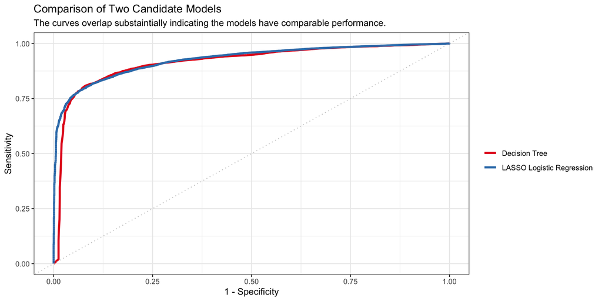

- Selected LASSO given marginally better performance.
- The model correctly classified 90.3% of all customers.

## Findings

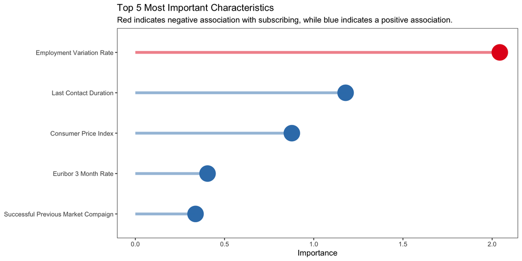

- When provided with a set of customer characteristics, the model can provide (1) the propensity of subscribing and (2) predict whether we expect them to subscribe (yes/no).

## Implications

To increase our chances of customers subscribing to a term deposit, we should focus on the following:

1. When employment variation rate is low and consumer price index and Euribor 3-month rate are high, we should be more aggressive in targeting our customers because they are more apt to subscribe.
2. The duration of our last contact was a key predictor of whether a customers subscribes, therefore we should increase duration of contacts. There is, however, likely an unknown upper limit.
3. The outcome of the previous marketing campaign matters. Need to ensure campaigns are successful!